# Analitica ifol_dm

### Conclusiones del Análisis ifol_diameter

A veces es mejor mantener los valores atípicos en sus datos. Pueden capturar información valiosa que sea parte de su área de estudio. Retener estos puntos puede ser difícil, ¡particularmente cuando reduce la significación estadística!, donde no es viable poder identificar si realmente los outilers son naturales o problemas específicos de la captura de datos. Por ejemplo, recordar que puede ser una variación natural con respecto al tiempo y genere valores atípicos.

Por lo tanto, se ha estudiado en diferentes momentos, para observar el comportamiento de los datos relacionados a su distribución y estimador puntual.

Bajo esta premisa, la dificultad en estimador, radica si tomar la mediana como estimación no paramétrica o irnos a un ajuste paramétrico basados en la media o en su caso si nos vamos a un estudio diferente de distribución, gama, beta entre otros.

#### Sobre Outliers

A grandes rasgos, hay tres causas para los valores atípicos: errores de medición o ingreso de datos, problemas de muestreo y condiciones inusuales, y variación natural.

El uso de pruebas de valores atípicos puede ser un desafío porque generalmente suponen que los datos siguen la distribución normal, y luego se produce enmascaramiento y saturación.

Si lo elimino, el modelo hace que el proceso parezca más predecible de lo que realmente es. Aunque esta inusual observación es influyente, la dejé en el modelo. Es una mala práctica eliminar puntos de datos simplemente para producir un modelo que se ajuste mejor o resultados estadísticamente significativos.

```r
library(ggplot2)
library(gridExtra)
library(MASS)
library(fitdistrplus)
library(ggstatsplot)
library(BSSasymp) #Cramer-ca
```

```r
### Ubicacion de datos
setwd("C:/hcgalvan/Repositorios/hcgalvan_project/data/union/End")
temp = gsub(".*target.*", "", readLines("seleccionestudio.csv"))
data<-read.table(text=temp, sep=",", header=TRUE)
ifoldm <-data$ifol_diameter
```

```r
fitData <- function(data, fit="gamma", sample=sample){
 distrib = list()
 numfit <- length(fit)
 results = matrix(0, ncol=5, nrow=numfit)

 for(i in 1:numfit){
if((fit[i] == "gamma") |
     (fit[i] == "poisson") |
     (fit[i] == "weibull") |
     (fit[i] == "exponential") |
     (fit[i] == "logistic") |
     (fit[i] == "normal") |
     (fit[i] == "geometric")
)
  distrib[[i]] = fit[i]
else stop("Provide a valid distribution to fit data" )
 }

 # take a sample of dataset
 n = round(length(data)*sample)
 data = sample(data, size=n, replace=F)

 for(i in 1:numfit) {
  if(distrib[[i]] == "gamma") {
  gf_shape = "gamma"
  fd_g <- fitdistr(data, "gamma")
  est_shape = fd_g$estimate[[1]]
  est_rate = fd_g$estimate[[2]]

  ks = ks.test(data, "pgamma", shape=est_shape, rate=est_rate)

  # add to results
  results[i,] = c(gf_shape, est_shape, est_rate, ks$statistic, ks$p.value)
}

else if(distrib[[i]] == "poisson"){
  gf_shape = "poisson"
  fd_p <- fitdistr(data, "poisson")
  est_lambda = fd_p$estimate[[1]]

  ks = ks.test(data, "ppois", lambda=est_lambda)
  # add to results
  results[i,] = c(gf_shape, est_lambda, "NA", ks$statistic, ks$p.value)
}

else if(distrib[[i]] == "weibull"){
  gf_shape = "weibull"
  fd_w <- fitdistr(data,densfun=dweibull,start=list(scale=1,shape=2))
  est_shape = fd_w$estimate[[1]]
  est_scale = fd_w$estimate[[2]]

  ks = ks.test(data, "pweibull", shape=est_shape, scale=est_scale)
  # add to results
  results[i,] = c(gf_shape, est_shape, est_scale, ks$statistic, ks$p.value)
}

else if(distrib[[i]] == "normal"){
  gf_shape = "normal"
  fd_n <- fitdistr(data, "normal")
  est_mean = fd_n$estimate[[1]]
  est_sd = fd_n$estimate[[2]]

  ks = ks.test(data, "pnorm", mean=est_mean, sd=est_sd)
  # add to results
  results[i,] = c(gf_shape, est_mean, est_sd, ks$statistic, ks$p.value)
}

else if(distrib[[i]] == "exponential"){
  gf_shape = "exponential"
  fd_e <- fitdistr(data, "exponential")
  est_rate = fd_e$estimate[[1]]
  ks = ks.test(data, "pexp", rate=est_rate)
  # add to results
  results[i,] = c(gf_shape, est_rate, "NA", ks$statistic, ks$p.value)
}

else if(distrib[[i]] == "logistic"){
  gf_shape = "logistic"
  fd_l <- fitdistr(data, "logistic")
  est_location = fd_l$estimate[[1]]
  est_scale = fd_l$estimate[[2]]
  ks = ks.test(data, "plogis", location=est_location, scale=est_scale)
  # add to results
  results[i,] = c(gf_shape, est_location, est_scale, ks$statistic,    ks$p.value)
    }
  }
  results = rbind(c("distribution", "param1", "param2", "ks stat", "ks    pvalue"),   results)
  #print(results)
  return(results)
  }
```

#### Tratamiento Ajustado a Distribución y comparativa con/sin outliers

Separamos los datos de la variable de estudio

```r
Control<-(as.numeric(unlist(subset(data, label==1, select=c(ifol_diameter)))))
Estudio<-(as.numeric(unlist(subset(data, label==0, select=c(ifol_diameter)))))
```

Ajustamos los outliers en base a Primer barrido.

```r
Q <- quantile(data$ifol_diameter, probs=c(.25, .75), na.rm = FALSE)
iqr <- IQR(data$ifol_diameter)
up <-  Q[2]+1.5*iqr # Upper Range
low<- Q[1]-1.5*iqr # Lower Range
datasinout<- subset(data, data$ifol_diameter > (Q[1] - 1.5*iqr) & data$ifol_diameter < (Q[2]+1.5*iqr))
```

Ajustamos los outliers en base a Segundo barrido.

```r
Q1 <- quantile(datasinout$ifol_diameter, probs=c(.25, .75), na.rm = FALSE)
iqr1 <- IQR(datasinout$ifol_diameter)
up1 <-  Q1[2]+1.5*iqr1 # Upper Range
low1<- Q1[1]-1.5*iqr1 # Lower Range
datasinout1<- subset(datasinout, datasinout$ifol_diameter > (Q1[1] - 1.5*iqr1) & datasinout$ifol_diameter < (Q1[2]+1.5*iqr1))
```

Ajustamos los outliers en Tercer barrido.

```r
Q1 <- quantile(datasinout1$ifol_diameter, probs=c(.25, .75), na.rm = FALSE)
iqr1 <- IQR(datasinout1$ifol_diameter)
up1 <-  Q1[2]+1.5*iqr1 # Upper Range
low1<- Q1[1]-1.5*iqr1 # Lower Range
datasinout2<- subset(datasinout1, datasinout1$ifol_diameter > (Q1[1] - 1.5*iqr1) & datasinout1$ifol_diameter < (Q1[2]+1.5*iqr1))
```

Ajustamos los outliers en Cuarto barrido

```r
Q1 <- quantile(datasinout2$ifol_diameter, probs=c(.25, .75), na.rm = FALSE)
iqr1 <- IQR(datasinout2$ifol_diameter)
up1 <-  Q1[2]+1.5*iqr1 # Upper Range
low1<- Q1[1]-1.5*iqr1 # Lower Range
datasinout3<- subset(datasinout2, datasinout2$ifol_diameter > (Q1[1] - 1.5*iqr1) & datasinout2$ifol_diameter < (Q1[2]+1.5*iqr1))
```

Graficamos la evolución y separamos los datos en 2 grupos: Estudio y Control

```
 [1]  7.88520  8.30575  9.38168  4.95215  3.93253  7.88520  8.30575  4.95215  8.76133  3.93253  9.06899  9.38168
[13]  9.92410 10.39000 11.00730
```

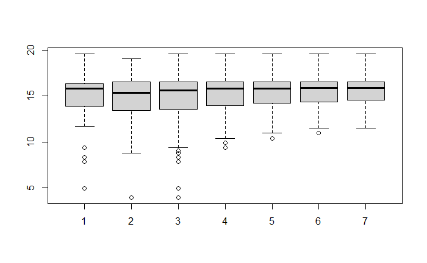

```r
boxplot(Control, Estudio, data$ifol_diameter, datasinout$ifol_diameter, datasinout1$ifol_diameter,datasinout2$ifol_diameter, datasinout3$ifol_diameter)$out
```

```r
library(diptest)
library(LaplacesDemon)

dip.test(datasinout2$ifol_diameter) #library diptest
```

```
    Hartigans' dip test for unimodality / multimodality

data:  datasinout2$ifol_diameter
D = 0.030021, p-value = 0.8671
alternative hypothesis: non-unimodal, i.e., at least bimodal
```

```r
is.unimodal(datasinout2$ifol_diameter) #library laplacesdemon
```

```
[1] TRUE
```

```r
is.multimodal(datasinout2$ifol_diameter) #library laplacesdemon
```

```
[1] FALSE
```

```r
is.bimodal(datasinout2$ifol_diameter) #library laplacesdemon
```

```
[1] FALSE
```

Graficamos las distribuciones obtenidos.

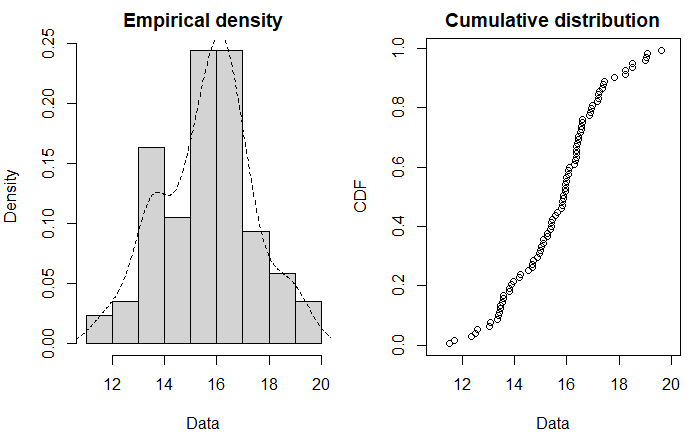

```r
par(mfrow = c(2, 2), mar = c(4, 4, 2, 1))
plotdist(datasinout3$ifol_diameter, histo=TRUE, demp=TRUE) #completamente ajustado en 3er capa.
```

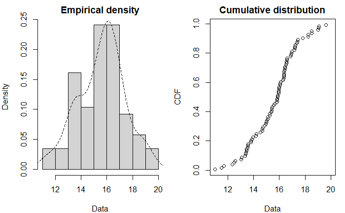

```r
plotdist(datasinout2$ifol_diameter, histo=TRUE, demp=TRUE) #completamente ajustado
```

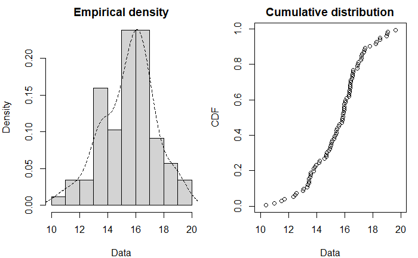

```r
plotdist(datasinout1$ifol_diameter, histo=TRUE, demp=TRUE) #completamente ajustado
```

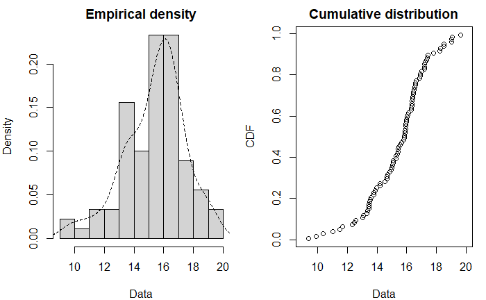

```r
plotdist(datasinout$ifol_diameter, histo=TRUE, demp=TRUE) # ajustado parcialmente
```

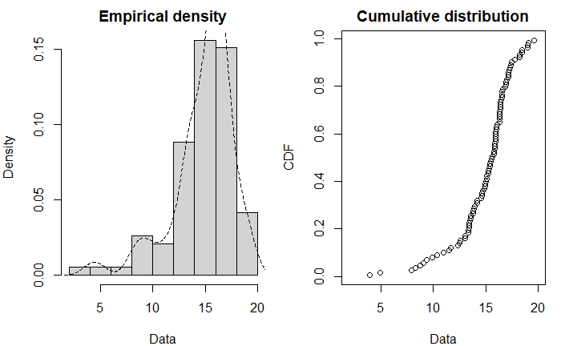

```r
plotdist(data$ifol_diameter, histo=TRUE, demp=TRUE) # sin ajustes en muestra
```

Realizamos descripcion de los valores descriptivos: Ajuste total, parcial y sin ajuste

```r
summary(datasinout3$ifol_diameter)
```

```
   Min. 1st Qu.  Median    Mean 3rd Qu.    Max.
  11.50   14.58   15.88   15.63   16.59   19.64
```

```r
summary(datasinout2$ifol_diameter)
```

```
   Min. 1st Qu.  Median    Mean 3rd Qu.    Max.
  11.01   14.38   15.87   15.58   16.58   19.64
```

```r
summary(datasinout1$ifol_diameter)
```

```
   Min. 1st Qu.  Median    Mean 3rd Qu.    Max.
  10.39   14.21   15.86   15.52   16.58   19.64
```

```r
summary(datasinout$ifol_diameter)
```

```
   Min. 1st Qu.  Median    Mean 3rd Qu.    Max.
  9.382  14.029  15.834  15.392  16.570  19.635
```